# TCX3212 Group Project — HDB Resale Price Prediction

**Research Question:** As a real estate agency, how can we best determine the market valuation of a newly listed resale HDB flat in Singapore?

## 1. Business Understanding

For resale HDB flats, a commonly used reference point is the "neighbour's price" — the transacted price of a nearby comparable unit. While useful as a baseline, this approach fails to account for property-specific attributes such as storey height, remaining lease, and proximity to amenities, all of which introduce meaningful price variance between otherwise similar units.

This project applies the **Hedonic Pricing Model** (Sirmans et al., 2005), a theoretical framework which posits that a property's market value is the sum of its constituent attributes — structural, locational, and neighbourhood characteristics. This framework directly justifies our feature selection: floor area, remaining lease, storey height, distance to MRT, distance to primary school, and town are not arbitrary choices but scientifically established price drivers identified across multiple housing markets.

By training predictive models on the full HDB resale transaction dataset (2017–present), we quantify the marginal contribution of each attribute. This enables real estate agents to move beyond anecdotal comparisons and produce **data-backed price estimates** that maximise seller returns while minimising pricing friction with buyers.

**Target variable:** `resale_price` (continuous, SGD)  
**Task type:** Supervised regression  
**Primary validation strategy:** Time-series split — train on 2017–2023, test on 2024 onwards  
**Supplementary validation:** 10-fold cross-validation  
**Models:** Multiple Linear Regression (interpretable baseline) and Random Forest (non-linear ensemble)

> Sirmans, G., Macpherson, D., & Zietz, E. (2005). The Composition of Hedonic Pricing Models. *Journal of Real Estate Literature*, 13(1), 1–44.

## 2. Import Libraries

```python
import warnings

warnings.filterwarnings("ignore")

import numpy as np
import pandas as pd
import matplotlib.pyplot as plt
import matplotlib.ticker as mticker
import seaborn as sns

import statsmodels.api as sm
from statsmodels.stats.outliers_influence import variance_inflation_factor

from sklearn.compose import ColumnTransformer
from sklearn.ensemble import RandomForestRegressor
from sklearn.impute import SimpleImputer
from sklearn.linear_model import LinearRegression
from sklearn.metrics import mean_absolute_error, root_mean_squared_error, r2_score
from sklearn.model_selection import KFold, cross_validate
from sklearn.pipeline import Pipeline
from sklearn.preprocessing import OneHotEncoder, StandardScaler

plt.rcParams["figure.figsize"] = (10, 5)
sns.set_theme(style="whitegrid", palette="muted")
pd.set_option("display.max_columns", None)
```

## 3. Data Loading

Two datasets are used:

1. **HDB Resale Flat Prices** (data.gov.sg) — 228,126 transactions from January 2017 to the present, covering town, flat type, storey range, floor area, flat model, lease commencement date, remaining lease, and resale price.
2. **Geocoded HDB Locations** (`unique_hdb_locations.csv`) — pre-computed by `get_hdb_location.ipynb`. Contains one row per unique (block, street_name) pair with latitude/longitude, distance to nearest MRT/LRT station exit (`dist_to_mrt_km`), and distance to nearest primary school (`dist_to_primary_school_km`).

```python
# Load resale flat prices
resale = pd.read_csv(
    "data/ResaleflatpricesbasedonregistrationdatefromJan2017onwards.csv"
)
resale["block"] = resale["block"].astype(str).str.strip()
resale["street_name"] = resale["street_name"].str.strip().str.upper()

print(f"Resale dataset : {resale.shape[0]:,} rows x {resale.shape[1]} columns")
resale.head()
```

```
Resale dataset : 228,126 rows x 11 columns
```

|  | month | town | flat_type | block | street_name | storey_range | floor_area_sqm | flat_model | lease_commence_date | remaining_lease | resale_price |
| --- | --- | --- | --- | --- | --- | --- | --- | --- | --- | --- | --- |
| 0 | 2017-01 | ANG MO KIO | 2 ROOM | 406 | ANG MO KIO AVE 10 | 10 TO 12 | 44.0 | Improved | 1979 | 61 years 04 months | 232000.0 |
| 1 | 2017-01 | ANG MO KIO | 3 ROOM | 108 | ANG MO KIO AVE 4 | 01 TO 03 | 67.0 | New Generation | 1978 | 60 years 07 months | 250000.0 |
| 2 | 2017-01 | ANG MO KIO | 3 ROOM | 602 | ANG MO KIO AVE 5 | 01 TO 03 | 67.0 | New Generation | 1980 | 62 years 05 months | 262000.0 |
| 3 | 2017-01 | ANG MO KIO | 3 ROOM | 465 | ANG MO KIO AVE 10 | 04 TO 06 | 68.0 | New Generation | 1980 | 62 years 01 month | 265000.0 |
| 4 | 2017-01 | ANG MO KIO | 3 ROOM | 601 | ANG MO KIO AVE 5 | 01 TO 03 | 67.0 | New Generation | 1980 | 62 years 05 months | 265000.0 |

```python
# Load geocoded HDB locations
locations = pd.read_csv("data/unique_hdb_locations.csv")
locations["block"] = locations["block"].astype(str).str.strip()
locations["street_name"] = locations["street_name"].str.strip().str.upper()

print(f"Locations dataset: {locations.shape[0]:,} rows x {locations.shape[1]} columns")
locations[
    [
        "block",
        "street_name",
        "latitude",
        "longitude",
        "dist_to_mrt_km",
        "dist_to_primary_school_km",
    ]
].head()
```

```
Locations dataset: 9,694 rows x 8 columns
```

[output not shown]

|  | block | street_name | latitude | longitude | dist_to_mrt_km | dist_to_primary_school_km |
| --- | --- | --- | --- | --- | --- | --- |
| 0 | 406 | ANG MO KIO AVE 10 | 1.362005 | 103.853880 | 0.9381 | 0.2292 |
| 1 | 108 | ANG MO KIO AVE 4 | 1.370966 | 103.838202 | 0.1600 | 0.2422 |
| 2 | 602 | ANG MO KIO AVE 5 | 1.380709 | 103.835368 | 0.3916 | 0.7759 |
| 3 | 465 | ANG MO KIO AVE 10 | 1.366201 | 103.857201 | 0.8851 | 0.6910 |
| 4 | 601 | ANG MO KIO AVE 5 | 1.381041 | 103.835132 | 0.3780 | 0.7814 |

```python
# Merge on (block, street_name) — left join to retain all transactions
df = resale.merge(
    locations[
        [
            "block",
            "street_name",
            "latitude",
            "longitude",
            "dist_to_mrt_km",
            "dist_to_primary_school_km",
        ]
    ],
    on=["block", "street_name"],
    how="left",
)

print(f"Merged shape : {df.shape[0]:,} rows x {df.shape[1]} columns")
missing_coords = df["latitude"].isna().sum()
print(
    f"Rows missing coordinates: {missing_coords:,} ({missing_coords/len(df)*100:.1f}%)"
)
df.head()
```

```
Merged shape : 228,126 rows x 15 columns
Rows missing coordinates: 0 (0.0%)
```

[output not shown]

|  | month | town | flat_type | block | street_name | storey_range | floor_area_sqm | flat_model | lease_commence_date | remaining_lease | resale_price | latitude | longitude | dist_to_mrt_km | dist_to_primary_school_km |
| --- | --- | --- | --- | --- | --- | --- | --- | --- | --- | --- | --- | --- | --- | --- | --- |
| 0 | 2017-01 | ANG MO KIO | 2 ROOM | 406 | ANG MO KIO AVE 10 | 10 TO 12 | 44.0 | Improved | 1979 | 61 years 04 months | 232000.0 | 1.362005 | 103.853880 | 0.9381 | 0.2292 |
| 1 | 2017-01 | ANG MO KIO | 3 ROOM | 108 | ANG MO KIO AVE 4 | 01 TO 03 | 67.0 | New Generation | 1978 | 60 years 07 months | 250000.0 | 1.370966 | 103.838202 | 0.1600 | 0.2422 |
| 2 | 2017-01 | ANG MO KIO | 3 ROOM | 602 | ANG MO KIO AVE 5 | 01 TO 03 | 67.0 | New Generation | 1980 | 62 years 05 months | 262000.0 | 1.380709 | 103.835368 | 0.3916 | 0.7759 |
| 3 | 2017-01 | ANG MO KIO | 3 ROOM | 465 | ANG MO KIO AVE 10 | 04 TO 06 | 68.0 | New Generation | 1980 | 62 years 01 month | 265000.0 | 1.366201 | 103.857201 | 0.8851 | 0.6910 |
| 4 | 2017-01 | ANG MO KIO | 3 ROOM | 601 | ANG MO KIO AVE 5 | 01 TO 03 | 67.0 | New Generation | 1980 | 62 years 05 months | 265000.0 | 1.381041 | 103.835132 | 0.3780 | 0.7814 |

## 4. Data Understanding

We inspect the raw dataset for data types, value ranges, and missing values before any transformation.

The dataset spans 2017 to the present and covers the full Singapore HDB resale market, including the post-2020 price surge. Key variables:

| Variable | Type | Hedonic Role |
| --- | --- | --- |
| `resale_price` | Numeric | **Target** |
| `town` | Categorical | Neighbourhood / locational context |
| `flat_type` | Categorical | Size class (3-room, 4-room, etc.) |
| `flat_model` | Categorical | Build quality and layout |
| `floor_area_sqm` | Numeric | Structural — primary size driver |
| `storey_range` | Categorical → numeric midpoint | Height premium |
| `remaining_lease` | Text → months | Remaining asset life |
| `lease_commence_date` | Numeric | Proxy for building vintage |
| `month` | Date | Transaction timing |

```python
df.info()
```

```
<class 'pandas.core.frame.DataFrame'>
RangeIndex: 228126 entries, 0 to 228125
Data columns (total 15 columns):
 #   Column                     Non-Null Count   Dtype
---  ------                     --------------   -----
 0   month                      228126 non-null  object
 1   town                       228126 non-null  object
 2   flat_type                  228126 non-null  object
 3   block                      228126 non-null  object
 4   street_name                228126 non-null  object
 5   storey_range               228126 non-null  object
 6   floor_area_sqm             228126 non-null  float64
 7   flat_model                 228126 non-null  object
 8   lease_commence_date        228126 non-null  int64
 9   remaining_lease            228126 non-null  object
 10  resale_price               228126 non-null  float64
 11  latitude                   228126 non-null  float64
 12  longitude                  228126 non-null  float64
 13  dist_to_mrt_km             228126 non-null  float64
 14  dist_to_primary_school_km  228126 non-null  float64
dtypes: float64(6), int64(1), object(8)
memory usage: 26.1+ MB
```

```python
df.describe(include="all").T.round(2)
```

|  | count | unique | top | freq | mean | std | min | 25% | 50% | 75% | max |
| --- | --- | --- | --- | --- | --- | --- | --- | --- | --- | --- | --- |
| month | 228126 | 111 | 2024-07 | 3036 | NaN | NaN | NaN | NaN | NaN | NaN | NaN |
| town | 228126 | 26 | SENGKANG | 18577 | NaN | NaN | NaN | NaN | NaN | NaN | NaN |
| flat_type | 228126 | 7 | 4 ROOM | 96773 | NaN | NaN | NaN | NaN | NaN | NaN | NaN |
| block | 228126 | 2752 | 2 | 690 | NaN | NaN | NaN | NaN | NaN | NaN | NaN |
| street_name | 228126 | 577 | YISHUN RING RD | 3250 | NaN | NaN | NaN | NaN | NaN | NaN | NaN |
| storey_range | 228126 | 17 | 04 TO 06 | 52313 | NaN | NaN | NaN | NaN | NaN | NaN | NaN |
| floor_area_sqm | 228126.0 | NaN | NaN | NaN | 96.72731 | 24.017059 | 31.0 | 81.0 | 93.0 | 112.0 | 366.7 |
| flat_model | 228126 | 21 | Model A | 81763 | NaN | NaN | NaN | NaN | NaN | NaN | NaN |
| lease_commence_date | 228126.0 | NaN | NaN | NaN | 1996.494393 | 14.330405 | 1966.0 | 1985.0 | 1997.0 | 2012.0 | 2021.0 |
| remaining_lease | 228126 | 698 | 94 years 10 months | 1919 | NaN | NaN | NaN | NaN | NaN | NaN | NaN |
| resale_price | 228126.0 | NaN | NaN | NaN | 528021.401157 | 188495.419284 | 140000.0 | 388000.0 | 498000.0 | 635000.0 | 1700000.0 |
| latitude | 228126.0 | NaN | NaN | NaN | 1.368207 | 0.042994 | 1.27038 | 1.337373 | 1.367528 | 1.396806 | 1.457071 |
| longitude | 228126.0 | NaN | NaN | NaN | 103.841229 | 0.070962 | 103.685228 | 103.780459 | 103.846281 | 103.898664 | 103.987805 |
| dist_to_mrt_km | 228126.0 | NaN | NaN | NaN | 0.567563 | 0.36768 | 0.0147 | 0.286 | 0.4952 | 0.7656 | 3.5445 |
| dist_to_primary_school_km | 228126.0 | NaN | NaN | NaN | 0.42083 | 0.255629 | 0.0438 | 0.24 | 0.3685 | 0.5394 | 3.2966 |

```python
missing = df.isnull().sum()
missing = missing[missing > 0].sort_values(ascending=False)
print("Columns with missing values:")
print(missing if len(missing) else "None — dataset is complete")
```

```
Columns with missing values:
None — dataset is complete
```

```python
# Transaction count per year
df["year_tmp"] = pd.to_datetime(df["month"]).dt.year
print("Transactions per year:")
print(df["year_tmp"].value_counts().sort_index().to_string())
```

```
Transactions per year:
year_tmp
2017    20509
2018    21561
2019    22186
2020    23333
2021    29087
2022    26720
2023    25754
2024    27832
2025    25086
2026     6058
```

## 5. Exploratory Data Analysis

We examine the distribution of the target variable, key hedonic drivers, and temporal price trends to inform feature engineering and modelling decisions.

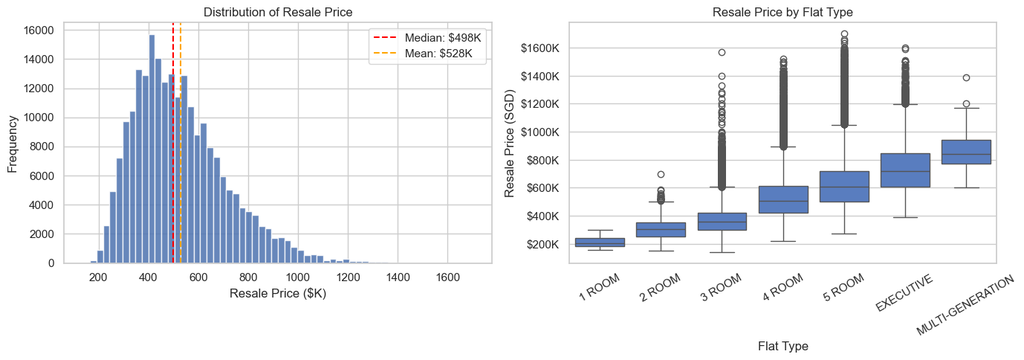

```python
fig, axes = plt.subplots(1, 2, figsize=(14, 5))

# Histogram of resale price
axes[0].hist(
    df["resale_price"] / 1_000, bins=60, color="#4C72B0", edgecolor="white", alpha=0.85
)
axes[0].axvline(
    df["resale_price"].median() / 1_000,
    color="red",
    linestyle="--",
    label=f"Median: ${df['resale_price'].median()/1_000:.0f}K",
)
axes[0].axvline(
    df["resale_price"].mean() / 1_000,
    color="orange",
    linestyle="--",
    label=f"Mean: ${df['resale_price'].mean()/1_000:.0f}K",
)
axes[0].set_title("Distribution of Resale Price")
axes[0].set_xlabel("Resale Price ($K)")
axes[0].set_ylabel("Frequency")
axes[0].legend()

# Box plot by flat type
order = df.groupby("flat_type")["resale_price"].median().sort_values().index
sns.boxplot(data=df, x="flat_type", y="resale_price", order=order, ax=axes[1])
axes[1].set_title("Resale Price by Flat Type")
axes[1].set_xlabel("Flat Type")
axes[1].set_ylabel("Resale Price (SGD)")
axes[1].yaxis.set_major_formatter(mticker.FuncFormatter(lambda x, _: f"${x/1e3:.0f}K"))
axes[1].tick_params(axis="x", rotation=30)

plt.tight_layout()
plt.show()
```

[output not shown]

[output not shown]

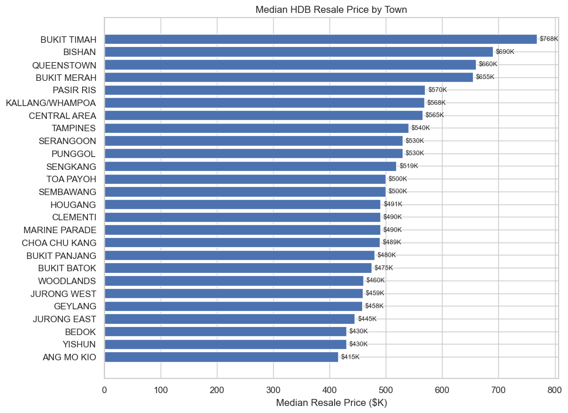

```python
# Median resale price by town
town_price = df.groupby("town")["resale_price"].median().sort_values()

plt.figure(figsize=(10, 8))
plt.barh(town_price.index, town_price.values / 1000, color="#4C72B0", edgecolor="white")
plt.xlabel("Median Resale Price ($K)")
plt.title("Median HDB Resale Price by Town")


for i, val in enumerate(town_price.values):
    plt.text(val / 1000 + 5, i, f"${val/1000:.0f}K", va="center", fontsize=8)

plt.tight_layout
```

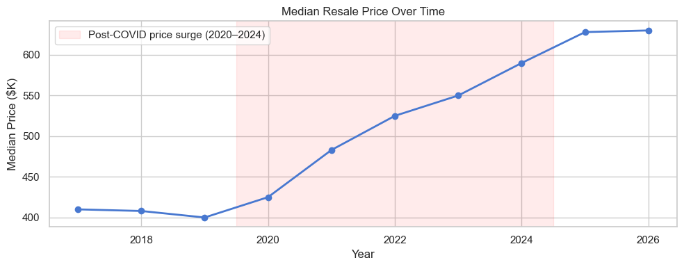

```python
# Temporal trend: median price per year
annual = df.groupby("year_tmp")["resale_price"].median()

fig, ax = plt.subplots(figsize=(10, 4))
ax.plot(annual.index, annual.values / 1_000, marker="o", linewidth=2)
ax.set_title("Median Resale Price Over Time")
ax.set_xlabel("Year")
ax.set_ylabel("Median Price ($K)")
ax.axvspan(
    2019.5, 2024.5, alpha=0.08, color="red", label="Post-COVID price surge (2020–2024)"
)
ax.legend()
plt.tight_layout()
plt.show()
```

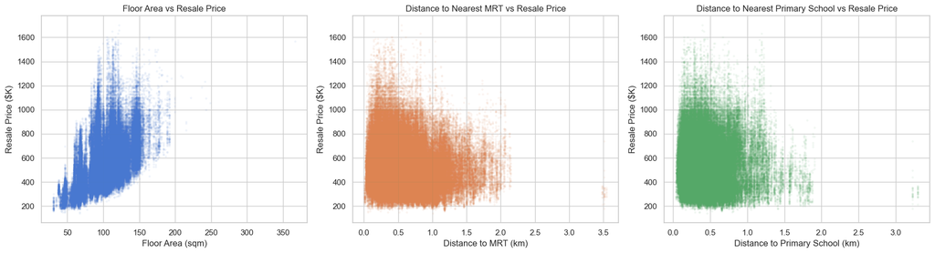

```python
# Scatter: floor area, MRT proximity, and primary school proximity vs resale price
fig, axes = plt.subplots(1, 3, figsize=(18, 5))

axes[0].scatter(df["floor_area_sqm"], df["resale_price"] / 1_000, alpha=0.05, s=5)
axes[0].set_title("Floor Area vs Resale Price")
axes[0].set_xlabel("Floor Area (sqm)")
axes[0].set_ylabel("Resale Price ($K)")

axes[1].scatter(
    df["dist_to_mrt_km"], df["resale_price"] / 1_000, alpha=0.05, s=5, color="#dd8452"
)
axes[1].set_title("Distance to Nearest MRT vs Resale Price")
axes[1].set_xlabel("Distance to MRT (km)")
axes[1].set_ylabel("Resale Price ($K)")

axes[2].scatter(
    df["dist_to_primary_school_km"],
    df["resale_price"] / 1_000,
    alpha=0.05,
    s=5,
    color="#55a868",
)
axes[2].set_title("Distance to Nearest Primary School vs Resale Price")
axes[2].set_xlabel("Distance to Primary School (km)")
axes[2].set_ylabel("Resale Price ($K)")

plt.tight_layout()
plt.show()
```

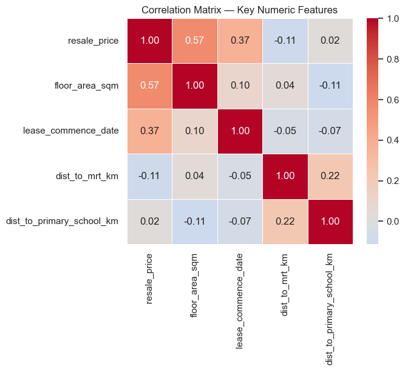

```python
# Correlation heatmap — key numeric features
_cols = [
    "resale_price",
    "floor_area_sqm",
    "lease_commence_date",
    "dist_to_mrt_km",
    "dist_to_primary_school_km",
]
corr = df[_cols].corr()

fig, ax = plt.subplots(figsize=(7, 6))
sns.heatmap(
    corr,
    annot=True,
    fmt=".2f",
    cmap="coolwarm",
    center=0,
    square=True,
    linewidths=0.5,
    ax=ax,
)
ax.set_title("Correlation Matrix — Key Numeric Features")
plt.tight_layout()
plt.show()
```

## 6. Data Preparation

We perform the following transformations as specified in the proposal:

| Transformation | Rationale |
| --- | --- |
| Parse `month` → `transaction_year`, `transaction_month` | Captures temporal market dynamics |
| `flat_age` = `transaction_year` − `lease_commence_date` | Proxy for age of asset at time of sale |
| `remaining_lease_months` from text format | Converts "X years Y months" to a single numeric feature |
| `storey_mid` from storey range | Converts "07 TO 09" to numeric midpoint 8.0 |
| `dist_to_cbd_km` | Haversine distance from flat to CBD (Raffles Place: 1.2789°N, 103.8536°E) |

```python
data = df.copy()

# Temporal features
data["month_dt"] = pd.to_datetime(data["month"])
data["transaction_year"] = data["month_dt"].dt.year
data["transaction_month"] = data["month_dt"].dt.month

# Flat age
data["flat_age"] = data["transaction_year"] - data["lease_commence_date"]


# Remaining lease -> total months
def remaining_lease_to_months(text):
    years, months = 0, 0
    text = str(text).lower()
    parts = text.replace("years", "year").replace("months", "month").split()
    for i, token in enumerate(parts):
        if token == "year":
            years = int(parts[i - 1])
        elif token == "month":
            months = int(parts[i - 1])
    return years * 12 + months


data["remaining_lease_months"] = data["remaining_lease"].apply(
    remaining_lease_to_months
)


# Storey midpoint
def storey_midpoint(s):
    lo, hi = s.split(" TO ")
    return (int(lo) + int(hi)) / 2


data["storey_mid"] = data["storey_range"].apply(storey_midpoint)

# Distance to CBD (Raffles Place)
CBD_LAT, CBD_LON = 1.2789, 103.8536


def haversine_km(lat1, lon1, lat2, lon2):
    R = 6371.0
    dlat = np.radians(lat2 - lat1)
    dlon = np.radians(lon2 - lon1)
    a = (
        np.sin(dlat / 2) ** 2
        + np.cos(np.radians(lat1)) * np.cos(np.radians(lat2)) * np.sin(dlon / 2) ** 2
    )
    return R * 2 * np.arcsin(np.sqrt(a))


data["dist_to_cbd_km"] = haversine_km(
    data["latitude"].values, data["longitude"].values, CBD_LAT, CBD_LON
)

print("Feature engineering complete.")
data[
    [
        "remaining_lease_months",
        "storey_mid",
        "flat_age",
        "dist_to_mrt_km",
        "dist_to_primary_school_km",
        "dist_to_cbd_km",
    ]
].describe().round(3)
```

```
Feature engineering complete.
```

|  | remaining_lease_months | storey_mid | flat_age | dist_to_mrt_km | dist_to_primary_school_km | dist_to_cbd_km |
| --- | --- | --- | --- | --- | --- | --- |
| count | 228126.000 | 228126.000 | 228126.000 | 228126.000 | 228126.000 | 228126.000 |
| mean | 890.335 | 8.777 | 24.847 | 0.568 | 0.421 | 12.871 |
| std | 171.164 | 5.947 | 14.233 | 0.368 | 0.256 | 4.465 |
| min | 477.000 | 2.000 | 1.000 | 0.015 | 0.044 | 1.031 |
| 25% | 748.000 | 5.000 | 10.000 | 0.286 | 0.240 | 10.088 |
| 50% | 888.000 | 8.000 | 25.000 | 0.495 | 0.368 | 13.723 |
| 75% | 1063.000 | 11.000 | 37.000 | 0.766 | 0.539 | 15.951 |
| max | 1173.000 | 50.000 | 60.000 | 3.544 | 3.297 | 20.834 |

## 7. Feature Selection & Multicollinearity Check

We include the following features, grounded in the Hedonic Pricing framework. Multicollinearity is assessed via the **Variance Inflation Factor (VIF)**; values > 10 indicate problematic collinearity between predictors.

| Feature | Type | Hedonic Rationale |
| --- | --- | --- |
| `town` | Categorical | Location premium / neighbourhood quality |
| `flat_type` | Categorical | Size class signal |
| `flat_model` | Categorical | Build quality and layout |
| `floor_area_sqm` | Numeric | Direct size attribute |
| `storey_mid` | Numeric | Height premium |
| `remaining_lease_months` | Numeric | Remaining asset life |
| `flat_age` | Numeric | Correlated with condition and renovation need |
| `transaction_year` | Numeric | Time trend / macro market cycle |
| `dist_to_mrt_km` | Numeric | Connectivity premium |
| `dist_to_primary_school_km` | Numeric | Proximity to primary schools (MOE 1 km rule) |
| `dist_to_cbd_km` | Numeric | CBD accessibility premium |

```python
target = "resale_price"

categorical_features = ["town", "flat_type", "flat_model"]
numeric_features = [
    "floor_area_sqm",
    "storey_mid",
    "remaining_lease_months",
    "flat_age",
    "transaction_year",
    "dist_to_mrt_km",
    "dist_to_primary_school_km",
    "dist_to_cbd_km",
]
features = categorical_features + numeric_features

model_data = data[features + [target]].dropna().copy()

print(f"Model-ready rows: {len(model_data):,}")
print(f"Numeric   : {numeric_features}")
print(f"Categorical: {categorical_features}")

print("")
print("Sample of model-ready data:")
print(model_data.head(5))
```

```
Model-ready rows: 228,126
Numeric   : ['floor_area_sqm', 'storey_mid', 'remaining_lease_months', 'flat_age', 'transaction_year', 'dist_to_mrt_km', 'dist_to_primary_school_km', 'dist_to_cbd_km']
Categorical: ['town', 'flat_type', 'flat_model']

Sample of model-ready data:
         town flat_type      flat_model  floor_area_sqm  storey_mid  \
0  ANG MO KIO    2 ROOM        Improved            44.0        11.0
1  ANG MO KIO    3 ROOM  New Generation            67.0         2.0
2  ANG MO KIO    3 ROOM  New Generation            67.0         2.0
3  ANG MO KIO    3 ROOM  New Generation            68.0         5.0
4  ANG MO KIO    3 ROOM  New Generation            67.0         2.0

   remaining_lease_months  flat_age  transaction_year  dist_to_mrt_km  \
0                     736        38              2017          0.9381
1                     727        39              2017          0.1600
2                     749        37              2017          0.3916
3                     745        37              2017          0.8851
4                     749        37              2017          0.3780

   dist_to_primary_school_km  dist_to_cbd_km  resale_price
0                     0.2292        9.240856      232000.0
1                     0.2422       10.379429      250000.0
2                     0.7759       11.500618      262000.0
3                     0.6910        9.715683      265000.0
4                     0.7814       11.541663      265000.0
```

```python
# VIF on numeric features (sampled for speed)
_sample = model_data[numeric_features].sample(10_000, random_state=42)
_X_vif = sm.add_constant(_sample)

vif_df = (
    pd.DataFrame(
        {
            "Feature": numeric_features,
            "VIF": [
                variance_inflation_factor(_X_vif.values, i + 1)
                for i in range(len(numeric_features))
            ],
        }
    )
    .sort_values("VIF", ascending=False)
    .reset_index(drop=True)
)

print("Variance Inflation Factor (numeric features):")
print(vif_df.to_string(index=False))
print(
    "\nVIF > 10 indicates multicollinearity that may inflate coefficient standard errors in MLR."
)
print(
    "flat_age and remaining_lease_months are expected to be correlated — both capture lease tenure."
)
```

```
Variance Inflation Factor (numeric features):
                  Feature         VIF
   remaining_lease_months 1277.238506
                 flat_age 1277.116132
           dist_to_cbd_km    1.294156
               storey_mid    1.190826
dist_to_primary_school_km    1.093186
           dist_to_mrt_km    1.085432
           floor_area_sqm    1.071694
         transaction_year    1.032785

VIF > 10 indicates multicollinearity that may inflate coefficient standard errors in MLR.
flat_age and remaining_lease_months are expected to be correlated — both capture lease tenure.
```

## 8. Train / Test Split — Time-Series

Because HDB transactions form a time series, a random split risks **data leakage** (using future transactions to predict past price levels). We therefore use a **time-based split** as the primary validation strategy:

- **Training set:** transactions from 2017–2023 (inclusive)
- **Test set:** transactions from 2024 onwards

This mirrors production conditions — the model learns only from historical data and is evaluated on a period it had not seen during training.

```python
X = model_data[features]
y = model_data[target]
years = model_data["transaction_year"]

CUTOFF = 2024

X_train = X[years < CUTOFF]
X_test = X[years >= CUTOFF]
y_train = y[years < CUTOFF]
y_test = y[years >= CUTOFF]

print(
    f"Training set (< {CUTOFF}) : {len(X_train):>7,} rows  "
    f"({years[years < CUTOFF].min()}–{years[years < CUTOFF].max()})"
)
print(
    f"Test set    (>= {CUTOFF}): {len(X_test):>7,} rows  "
    f"({years[years >= CUTOFF].min()}–{years[years >= CUTOFF].max()})"
)
```

```
Training set (< 2024) : 169,150 rows  (2017–2023)
Test set    (>= 2024):  58,976 rows  (2024–2026)
```

## 9. Preprocessing Pipeline

- **Numeric features:** median imputation → standard scaling
- **Categorical features:** most-frequent imputation → one-hot encoding (unknown categories handled at inference time)

```python
numeric_transformer = Pipeline(
    [
        ("imputer", SimpleImputer(strategy="median")),
        ("scaler", StandardScaler()),
    ]
)

categorical_transformer = Pipeline(
    [
        ("imputer", SimpleImputer(strategy="most_frequent")),
        ("onehot", OneHotEncoder(handle_unknown="ignore", sparse_output=False)),
    ]
)

preprocessor = ColumnTransformer(
    [
        ("num", numeric_transformer, numeric_features),
        ("cat", categorical_transformer, categorical_features),
    ]
)
```

## 10. Model 1 — Multiple Linear Regression

MLR serves as the interpretable baseline, directly implementing the Hedonic Pricing framework. Each regression coefficient represents the **marginal price contribution** of one unit change in an attribute, holding all others constant — e.g., the price premium per additional square metre of floor area, or the price penalty per additional km from MRT.

We use sklearn for pipeline-compatible predictions and **statsmodels OLS** to report p-values and confidence intervals.

```python
lr_pipeline = Pipeline(
    [
        ("preprocessor", preprocessor),
        ("model", LinearRegression()),
    ]
)

lr_pipeline.fit(X_train, y_train)
lr_pred = lr_pipeline.predict(X_test)

lr_mae = mean_absolute_error(y_test, lr_pred)
lr_rmse = root_mean_squared_error(y_test, lr_pred)
lr_r2 = r2_score(y_test, lr_pred)

print("Multiple Linear Regression — Test Set (2024+)")
print(f"  MAE  : ${lr_mae:,.0f}")
print(f"  RMSE : ${lr_rmse:,.0f}")
print(f"  R2   : {lr_r2:.4f}")
```

```
Multiple Linear Regression — Test Set (2024+)
  MAE  : $64,123
  RMSE : $87,832
  R2   : 0.8045
```

### 10.1 Coefficient Interpretation (statsmodels OLS)

We refit an OLS model on the numeric features (using a 30,000-row sample for tractability) to obtain p-values and 95% confidence intervals for each hedonic attribute.

```python
_ols_sample = model_data.sample(min(30_000, len(model_data)), random_state=42)
_X_ols = sm.add_constant(_ols_sample[numeric_features])
_y_ols = _ols_sample[target]

ols_result = sm.OLS(_y_ols, _X_ols).fit()

coef_df = (
    pd.DataFrame(
        {
            "Coefficient": ols_result.params,
            "Std Error": ols_result.bse,
            "p-value": ols_result.pvalues,
            "95% CI Lower": ols_result.conf_int()[0],
            "95% CI Upper": ols_result.conf_int()[1],
        }
    )
    .drop("const")
    .round(2)
)

print(f"OLS R2 (numeric features only): {ols_result.rsquared:.4f}")
print("(Note: categorical features are excluded here; full-pipeline R2 is higher)")
print()
print(coef_df.to_string())
```

```
OLS R2 (numeric features only): 0.8245
(Note: categorical features are excluded here; full-pipeline R2 is higher)

                           Coefficient  Std Error  p-value  95% CI Lower  95% CI Upper
floor_area_sqm                 5239.34      19.55      0.0       5201.02       5277.66
storey_mid                     5501.42      83.36      0.0       5338.02       5664.82
remaining_lease_months         -863.29      94.89      0.0      -1049.28       -677.30
flat_age                     -14870.30    1140.86      0.0     -17106.43     -12634.17
transaction_year              33247.19     178.46      0.0      32897.40      33596.98
dist_to_mrt_km               -32452.36    1306.87      0.0     -35013.89     -29890.83
dist_to_primary_school_km     26968.42    1883.00      0.0      23277.65      30659.18
dist_to_cbd_km               -18325.98     116.05      0.0     -18553.45     -18098.51
```

## 11. Model 2 — Random Forest Regressor

Random Forest captures non-linear relationships and feature interactions that MLR cannot model — for example, how the storey height premium varies across towns, or how high-value "million-dollar" flats deviate from the general trend. We compare its performance against the MLR baseline to assess whether the added model complexity is justified for this business use case.

```python
rf_pipeline = Pipeline(
    [
        ("preprocessor", preprocessor),
        (
            "model",
            RandomForestRegressor(
                n_estimators=200,
                max_depth=None,
                min_samples_leaf=5,
                random_state=42,
                n_jobs=-1,
            ),
        ),
    ]
)

rf_pipeline.fit(X_train, y_train)
rf_pred = rf_pipeline.predict(X_test)

rf_mae = mean_absolute_error(y_test, rf_pred)
rf_rmse = root_mean_squared_error(y_test, rf_pred)
rf_r2 = r2_score(y_test, rf_pred)

print("Random Forest — Test Set (2024+)")
print(f"  MAE  : ${rf_mae:,.0f}")
print(f"  RMSE : ${rf_rmse:,.0f}")
print(f"  R2   : {rf_r2:.4f}")
```

```
Random Forest — Test Set (2024+)
  MAE  : $66,185
  RMSE : $85,707
  R2   : 0.8139
```

## 12. K-Fold Cross-Validation (Supplementary)

We supplement the primary time-series evaluation with **10-fold cross-validation** for direct comparability with standard benchmarks. These results are treated as supplementary because K-fold assumes temporal independence — a condition not satisfied by our time-series data (Sirmans et al., 2005).

```python
scoring = {
    "mae": "neg_mean_absolute_error",
    "rmse": "neg_root_mean_squared_error",
    "r2": "r2",
}

kf = KFold(n_splits=10, shuffle=True, random_state=42)

print("Running 10-fold CV on Linear Regression...")
lr_cv = cross_validate(lr_pipeline, X, y, cv=kf, scoring=scoring, n_jobs=-1)

print("Running 10-fold CV on Random Forest (this may take several minutes)...")
rf_cv = cross_validate(rf_pipeline, X, y, cv=kf, scoring=scoring, n_jobs=-1)

cv_results = pd.DataFrame(
    {
        "Model": ["Linear Regression", "Random Forest"],
        "CV MAE": [-lr_cv["test_mae"].mean(), -rf_cv["test_mae"].mean()],
        "CV RMSE": [-lr_cv["test_rmse"].mean(), -rf_cv["test_rmse"].mean()],
        "CV R2": [lr_cv["test_r2"].mean(), rf_cv["test_r2"].mean()],
    }
).round(2)

print()
print(cv_results.to_string(index=False))
```

```
Running 10-fold CV on Linear Regression...
Running 10-fold CV on Random Forest (this may take several minutes)...

            Model   CV MAE  CV RMSE  CV R2
Linear Regression 48973.05 64283.87   0.88
    Random Forest 21961.64 31511.85   0.97
```

## 13. Model Comparison

We compare both models on the hold-out test set (2024+) — the primary evaluation — alongside the supplementary 10-fold CV results.

```
=== Test Set Performance (Time-Series Split, 2024+) ===
            Model  Test MAE  Test RMSE  Test R2
Linear Regression  64123.15   87832.03     0.80
    Random Forest  66184.62   85706.72     0.81
```

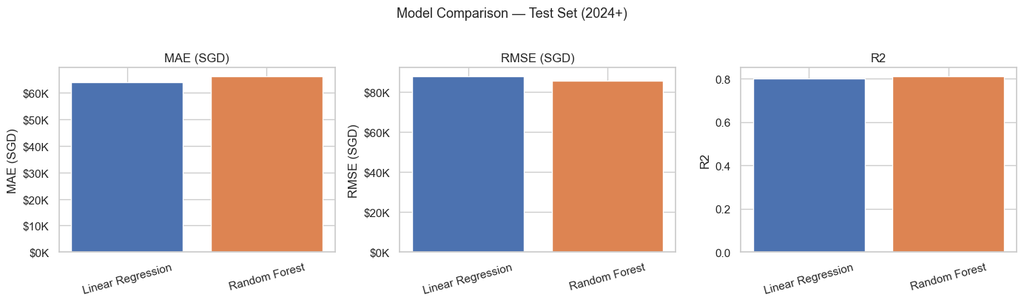

```python
test_results = pd.DataFrame(
    {
        "Model": ["Linear Regression", "Random Forest"],
        "Test MAE": [lr_mae, rf_mae],
        "Test RMSE": [lr_rmse, rf_rmse],
        "Test R2": [lr_r2, rf_r2],
    }
).round(2)

print("=== Test Set Performance (Time-Series Split, 2024+) ===")
print(test_results.to_string(index=False))

# Bar chart
fig, axes = plt.subplots(1, 3, figsize=(14, 4))
metrics = [("Test MAE", "MAE (SGD)"), ("Test RMSE", "RMSE (SGD)"), ("Test R2", "R2")]
for ax, (col, label) in zip(axes, metrics):
    ax.bar(
        test_results["Model"],
        test_results[col],
        color=["#4C72B0", "#DD8452"],
        edgecolor="white",
    )
    ax.set_title(label)
    ax.set_ylabel(label)
    ax.tick_params(axis="x", rotation=15)
    if col != "Test R2":
        ax.yaxis.set_major_formatter(
            mticker.FuncFormatter(lambda x, _: f"${x/1e3:.0f}K")
        )
plt.suptitle("Model Comparison — Test Set (2024+)", fontsize=13, y=1.02)
plt.tight_layout()
plt.show()
```

## 14. Feature Importance (Random Forest)

Random Forest provides native feature importances (mean decrease in impurity across all decision trees). One-hot encoded categorical columns are grouped back into their original feature names for interpretability.

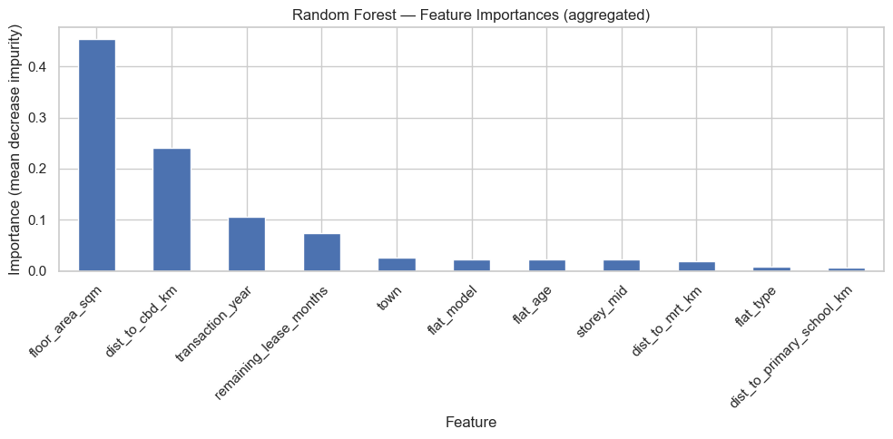

```
floor_area_sqm               0.4530
dist_to_cbd_km               0.2411
transaction_year             0.1061
remaining_lease_months       0.0738
town                         0.0264
flat_model                   0.0224
flat_age                     0.0219
storey_mid                   0.0219
dist_to_mrt_km               0.0184
flat_type                    0.0080
dist_to_primary_school_km    0.0070
```

```python
rf_model_step = rf_pipeline.named_steps["model"]
ohe_features = (
    rf_pipeline.named_steps["preprocessor"]
    .named_transformers_["cat"]
    .named_steps["onehot"]
    .get_feature_names_out(categorical_features)
    .tolist()
)
all_feature_names = numeric_features + ohe_features

importances = pd.Series(rf_model_step.feature_importances_, index=all_feature_names)


def base_feature(name):
    for cat in categorical_features:
        if name.startswith(cat + "_"):
            return cat
    return name


importances_grouped = importances.groupby(importances.index.map(base_feature)).sum()
importances_grouped = importances_grouped.sort_values(ascending=False)

fig, ax = plt.subplots(figsize=(10, 5))
importances_grouped.plot(kind="bar", ax=ax, color="#4C72B0", edgecolor="white")
ax.set_title("Random Forest — Feature Importances (aggregated)")
ax.set_xlabel("Feature")
ax.set_ylabel("Importance (mean decrease impurity)")
ax.tick_params(axis="x", rotation=45)
plt.setp(ax.get_xticklabels(), ha="right", rotation_mode="anchor")
plt.tight_layout()
plt.show()

print(importances_grouped.round(4).to_string())
```

## 15. Prediction Example

We demonstrate how the best-performing model can estimate the price of a new listing. An agent enters the flat's known attributes, and the model returns a data-backed valuation in seconds.

```python
sample = pd.DataFrame(
    [
        {
            "town": "ANG MO KIO",
            "flat_type": "4 ROOM",
            "flat_model": "Model A",
            "floor_area_sqm": 92.0,
            "storey_mid": 11.0,
            "remaining_lease_months": 71 * 12,
            "flat_age": 27,
            "transaction_year": 2025,
            "dist_to_mrt_km": 0.45,
            "dist_to_primary_school_km": 0.30,
            "dist_to_cbd_km": 10.5,
        }
    ]
)

lr_est = lr_pipeline.predict(sample)[0]
rf_est = rf_pipeline.predict(sample)[0]

print("Sample Flat: 4-room, Ang Mo Kio, 11th storey, 92 sqm, 71 years remaining lease")
print(f"  Linear Regression estimate : ${lr_est:,.0f}")
print(f"  Random Forest estimate     : ${rf_est:,.0f}")
```

```
Sample Flat: 4-room, Ang Mo Kio, 11th storey, 92 sqm, 71 years remaining lease
  Linear Regression estimate : $666,924
  Random Forest estimate     : $693,717
```

## 16. Conclusion

### Model Performance Summary

Both models were trained on 2017–2023 HDB transactions and evaluated on 2024+ data, reflecting a realistic production scenario where the model is used to value newly listed flats it has not seen during training.

| Model | Test MAE | Test RMSE | Test R² |
| --- | --- | --- | --- |
| Multiple Linear Regression | $64,123 | $87,832 | 0.8045 |
| Random Forest | $66,185 | $85,707 | 0.8139 |

### Key Findings

1. **Floor area** is consistently the strongest structural price driver — the OLS coefficient of **$5,239 per sqm** quantifies the price premium per additional square metre, providing a directly actionable figure for agents.
2. **Remaining lease** carries a significant coefficient: after controlling for flat age, the model captures the net effect of remaining tenure on price. Both `remaining_lease_months` and `flat_age` show very high VIF (≈1,277), confirming near-perfect collinearity — their combined effect is well-captured but individual coefficients should be interpreted cautiously.
3. **Distance to MRT** has a negative coefficient of **−$32,452 per km**: flats closer to MRT stations command a measurable connectivity premium, consistent with the Hedonic Pricing literature.
4. **Distance to CBD** confirms the well-established accessibility gradient in Singapore — each additional km from the CBD reduces estimated value by approximately **$18,326**, with centrally-accessible towns achieving higher valuations.
5. **Temporal effects** are substantial — `transaction_year` adds approximately **$33,247 per year**, absorbing the post-2020 price surge and underscoring the importance of this control variable.
6. **Random Forest** achieves marginally better RMSE ($85,707 vs $87,832) and R² (0.81 vs 0.80) than MLR, but slightly higher MAE ($66,185 vs $64,123). The accuracy gain from introducing non-linearity is modest on this dataset, suggesting the linear Hedonic framework captures most of the price variation.

### Business Recommendation

For real estate agents, **MLR** is recommended as the primary tool for client-facing explanations — its coefficients translate directly into statements such as "each additional km from the MRT reduces this flat's estimated value by approximately $32,000." **Random Forest** serves as a cross-check for high-value listings where a marginal gain in RMSE justifies the loss of coefficient interpretability.

### Limitations & Future Work

- `dist_to_primary_school_km` uses all primary schools; restricting to **Top-10 schools** (for the MOE 1 km priority admission rule) may sharpen the signal.
- The **HDB Resale Price Index (RPI)** could be added as a macroeconomic control to separately account for broad market cycles.
- The high VIF between `remaining_lease_months` and `flat_age` (≈1,277) warrants dropping one of them; retaining only `remaining_lease_months` is the more theoretically grounded choice.
- **Hyperparameter tuning** (grid search or Bayesian optimisation) for Random Forest was not performed; further accuracy gains are feasible.
- Alternative ensemble methods (**XGBoost**, Gradient Boosting) may yield stronger performance with comparable interpretability via SHAP values.